# Dist order subset traits

Léo Delalandre

To start with, it is noteworthy that the simulations take a long time to run, so I could not run them again in so little time. Consequently, in this document, I only use distinctiveness order computed with different subset of traits or species, and correlate it to the distinctiveness order computed on 14 traits and on all the species, which is what we used in the experimental design.

# Part 1: Sensibility of species distinctiveness order to the traits chosen to compute it

First, I computed functional distinctiveness on all the traits that were used to design our simulations. Then, I did it on a subset of traits excluding environmental response traits. I plotted one against the other, and I also computed Spearman’s rank correlation coefficient (which answers Annette’s question: Is there some way to look at the data that way–rank in distinctiveness with all traits, vs with the subset?). The value given is the correlation coefficient.

(The traits included for computing the second disctinctiveness index are: HMax, AMax, G, Brow, Ly, La,S,A1max, A2.)

```
## [1] 0.8580645
```

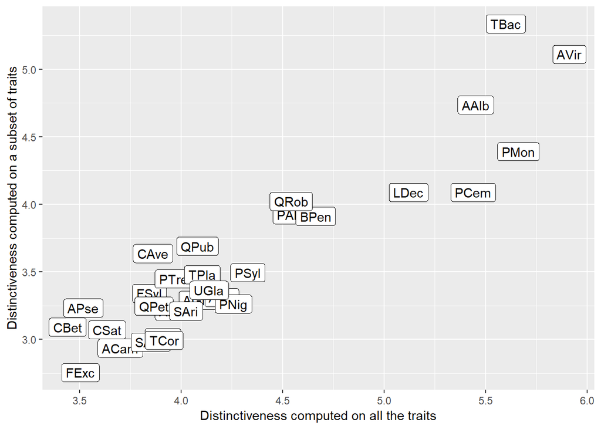

The correlation between distinctiveness orders is rather high in that case : distinct species remain distinct even when we remove direct environmental response traits (drought and nitrogen tolerance, temperature response traits). (Note that the correlation is not as pretty a what I sent you: my bad, I did it too fast and there was a mistake hidden in my codes).

I then followed the same procedure after having removed the allometry traits too (S,A1max,A2: diameter-height and crown size parameters). Here, the correlation coefficient decreases:

```
## [1] 0.6115684
```

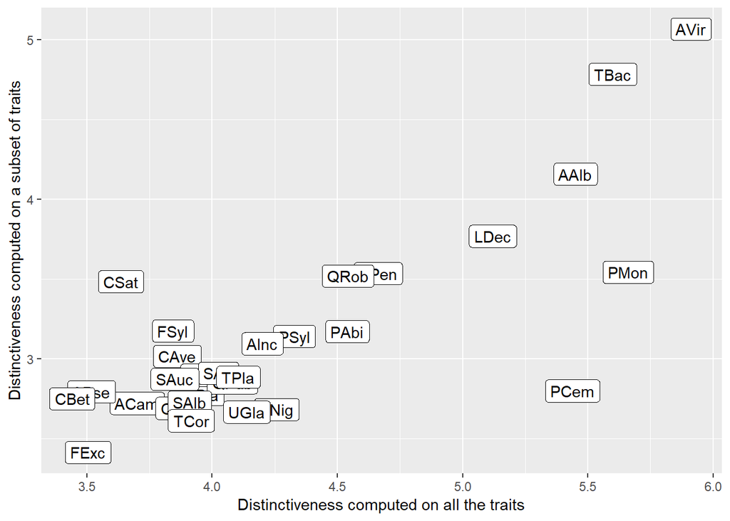

Of peculiar interest is that PCem (Pinus cembra), which is one of the most productive species in cold sites, does not appear so distinct anymore. Does it mean that the distinctiveness of one of the most important species for ecosystem productivity in cold environments relies mostly on the three allometry parameters ?

To test it, I compared distinctiveness computed on all the traits and all minus the three allometry parameters.

```
## [1] 0.9070078
```

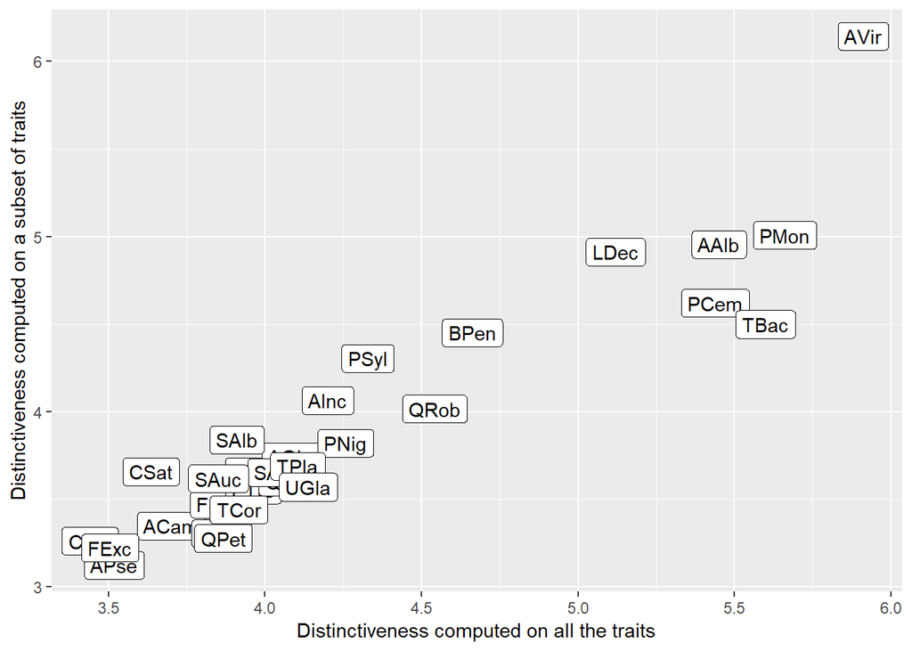

This time, PCem remains distinct. The info about its distinctiveness seems to be conveyed by both its environmental response and allometry traits…

If, on the contrary, I compute only distinctiveness on environmental response traits, here’s what I get:

```
## [1] 0.6867631
```

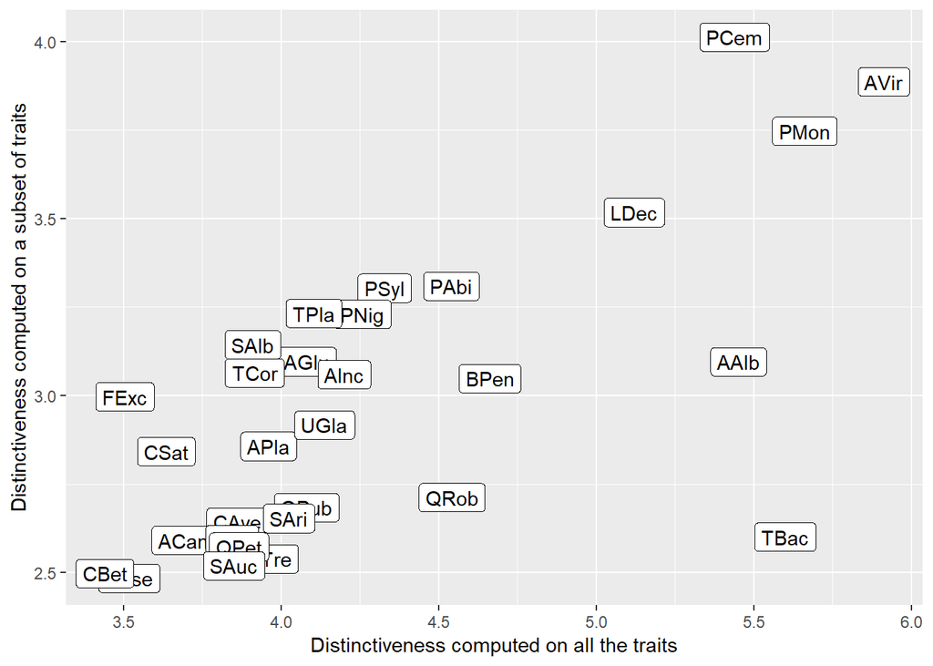

Important species for productivity in cold environments remain distinct here (TBac, Taxus baccata and AAlb, Abies alba, get less distinct, but they were not among the most productive).

# Part 2: Distinctiveness computed on the local (instead of regional) pool of species

Now, I turn to the second question you asked, Annette: “would it also make sense to think about removing the species that are most distinctive locally?”

Here is the beginning of an answer to it. What I did was: 1) I grew each species in monocultures in every site. This gave me the “local pool” of species in each site, i.e. the species that can grow there when there is no interspecific competition. 2)For each site, I computed a distinctiveness order on these species alone. 3) In each site, I correlated that order with the order of the same species calculated when distinctiveness was computed on all the species. Here again, I used Spearman’s rank-order correlation coefficient (column cor_site).

Note that the number of species persisting in each site is given in the right column of the table. Sites are ordered from cold (first line) to dry-warm (last line). (The cases where not enough species persisted that we mentioned during the zoom session was when we grew them in mixture, i.e. adding interspecific competition, see the end of this document).

```
##             SITE  cor_site nb_sp
## 1  GrandeDixence 0.8041958    12
## 2          Bever 0.5245098    17
## 3          Davos 0.4771930    19
## 4      Adelboden 1.0000000    30
## 5        Huttwil 1.0000000    30
## 6       Schwerin 1.0000000    30
## 7           Bern 1.0000000    30
## 8        Cottbus 1.0000000    30
## 9          Basel 1.0000000    30
## 10  Schaffhausen 1.0000000    30
## 11          Sion 1.0000000    30
```

It is true that in the cold sites, and especially Bever and Davos, the distinctiveness order is quite different, if we look at the correlation coefficient. I the other sites, the regional pool of species equals the local pool of species (defined as the species persisting in monoculture).

I look at Bever, a site where the correlation coefficient is low. First, I test statistically if it differs from zero (using the cor.test function):

```
##
##  Spearman's rank correlation rho
##
## data:  A$Di and B$Di
## S = 388, p-value = 0.03272
## alternative hypothesis: true rho is not equal to 0
## sample estimates:
##       rho
## 0.5245098
```

Now I look at the abundance~distinctiveness relationship using the distinctiveness computed locally.

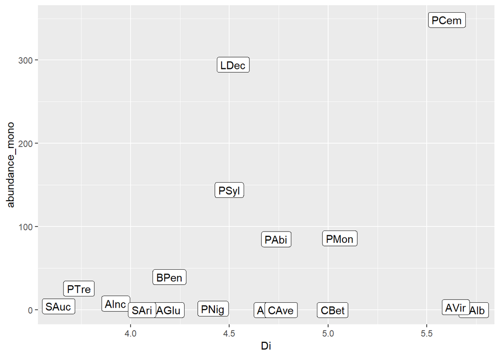

The most abundant species are still among the most distinct. So the results seem to hold for the local pool even in a site where the distinctiveness order varies a bit (though not significantly if we refer to the correlation test).

Finally, you said: “Though it is perhaps interesting to point that out it does seem that it is driven more by what environment distinct traits are found in and not some special position of distinct species within a community–i.e. it does not speak so much to how community assembly processes are driving diversity function relationships.

This brings me to ask would it also make sense to think about removing the species that are most distinctive locally?"

One last option would be to recompute functional distinctiveness on the species that persist in mixtures containing all the species at the beginning. This is the case were really few species persist in the cold sites (the three first sites in the following table).

```
##             SITE   cor_site nb_sp
## 1  GrandeDixence -0.8000000     4
## 2          Bever  0.8818182    11
## 3          Davos  0.9000000     5
## 4      Adelboden  0.5208791    14
## 5        Huttwil  0.8224974    18
## 6       Schwerin  0.5785714    15
## 7           Bern  0.8052632    19
## 8        Cottbus  0.5872033    18
## 9          Basel  0.7426471    17
## 10  Schaffhausen  0.7892157    17
## 11          Sion  0.9562124    28
```

Here, the distinctiveness order seems to be rather different in some sites (such as Adelboden, Schwerin or Cottbus) to that computed in all the sites.

I could run some simulations in this sites to see what happens when locally distinct species are removed first. An I could do it with a distinctiveness index computed on all the traits, or only a subset of them. We can think about all of this if anyone managed to go through the document up to this point!

Léo